# CannaQuant - Descriptives

28 July 2024

# Data cleaned

in “clean data.R”

Switzerland and Germany: missing value in sex OR age OR education

All other countries: missing value in sex OR age

Reason: many missing values in education in most countries –> Arto to check the data!

# Sample characteristics

First let’s look at country-specific distributions

## RESPONSES

How many valid responses are there in each country?

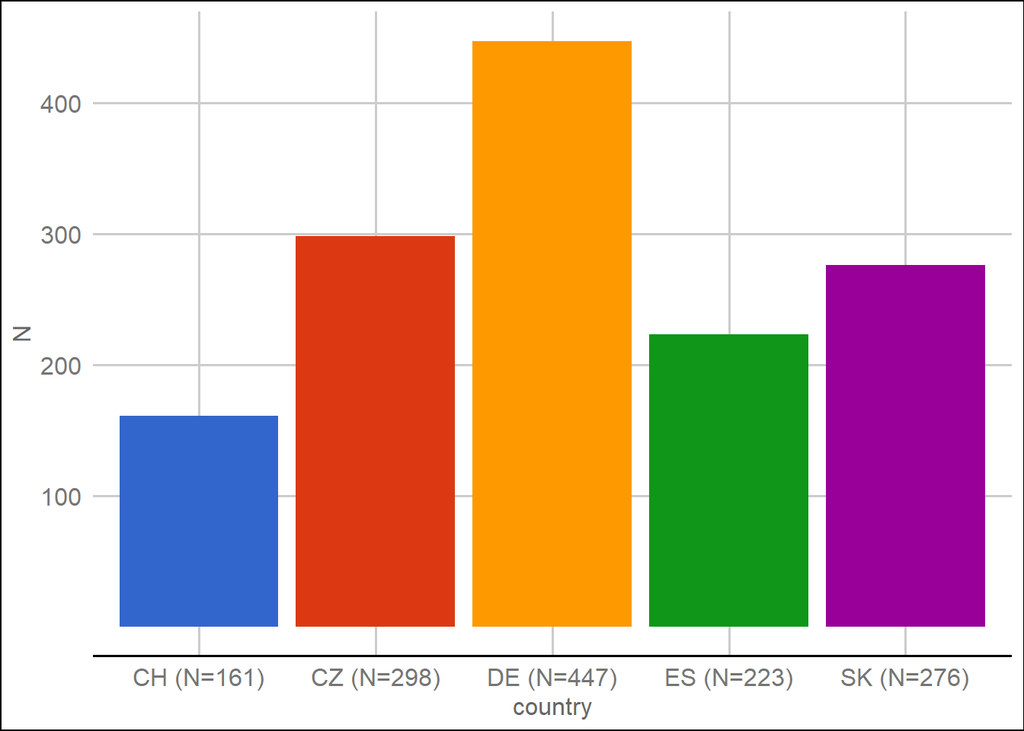

## SOCIODEMOGRAPHICS

How are sex, age, and education distributed?

```
##        country share_men age_mean age_median age_IQR   edu_low  edu_high
##         <fctr>     <num>    <num>      <num>  <char>     <num>     <num>
## 1:     Czechia 0.7818792 22.86577         21   18-24        NA        NA
## 2:     Germany 0.8993289 37.43624         37   30-43 0.1431767 0.3534676
## 3:    Slovakia 0.7210145 29.90942         29   24-35        NA        NA
## 4:       Spain 0.6278027 30.59193         28   23-38        NA        NA
## 5: Switzerland 0.7142857 30.14286         25   21-37 0.1118012 0.2608696
```

```
##
## Call:
## glm(formula = age ~ relevel(country, ref = "Germany"), family = "gaussian",
##     data = data)
##
## Deviance Residuals:
##     Min       1Q   Median       3Q      Max
## -19.436   -5.909   -1.866    4.857   35.857
##
## Coefficients:
##                                              Estimate Std. Error t value
## (Intercept)                                   37.4362     0.4273  87.613
## relevel(country, ref = "Germany")Czechia     -14.5705     0.6756 -21.567
## relevel(country, ref = "Germany")Slovakia     -7.5268     0.6916 -10.884
## relevel(country, ref = "Germany")Spain        -6.8443     0.7406  -9.241
## relevel(country, ref = "Germany")Switzerland  -7.2934     0.8304  -8.783
##                                                         Pr(>|t|)
## (Intercept)                                  <0.0000000000000002 ***
## relevel(country, ref = "Germany")Czechia     <0.0000000000000002 ***
## relevel(country, ref = "Germany")Slovakia    <0.0000000000000002 ***
## relevel(country, ref = "Germany")Spain       <0.0000000000000002 ***
## relevel(country, ref = "Germany")Switzerland <0.0000000000000002 ***
## ---
## Signif. codes:  0 '***' 0.001 '**' 0.01 '*' 0.05 '.' 0.1 ' ' 1
##
## (Dispersion parameter for gaussian family taken to be 81.61206)
##
##     Null deviance: 152971  on 1404  degrees of freedom
## Residual deviance: 114257  on 1400  degrees of freedom
## AIC: 10179
##
## Number of Fisher Scoring iterations: 2
```

```
## [1] "Respondents are youngest in Czechia and oldest in Germany"
```

IGNORE THE EDUCATION DISTRIBUTION FOR NOW!

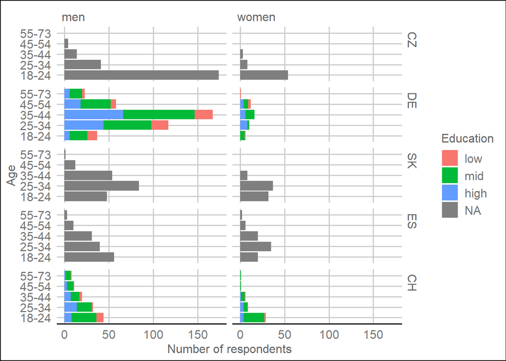

## CANNABIS USE FREQUENCY

How is cannabis use frequency distributed in the different countries?

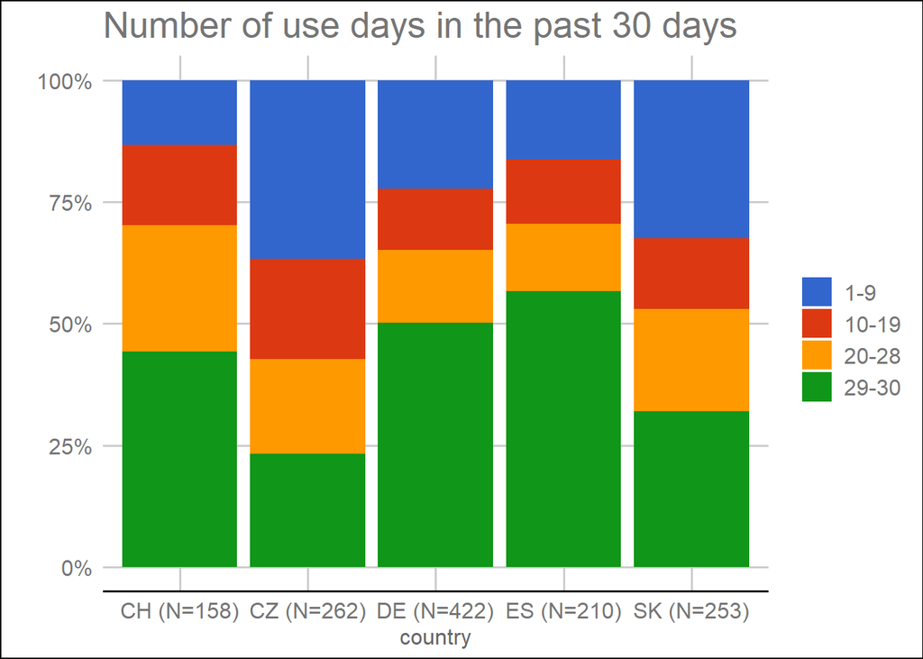

```
## [1] "About 50% of respondents use cannabis (near) daily in CH, DE and ES and the percentage is at about 25% in CZ and SK"
```

## CAST SCORE

How is the CAST score distributed in the different countries? Cutoff >= 7 indicates risk for severe use disorder

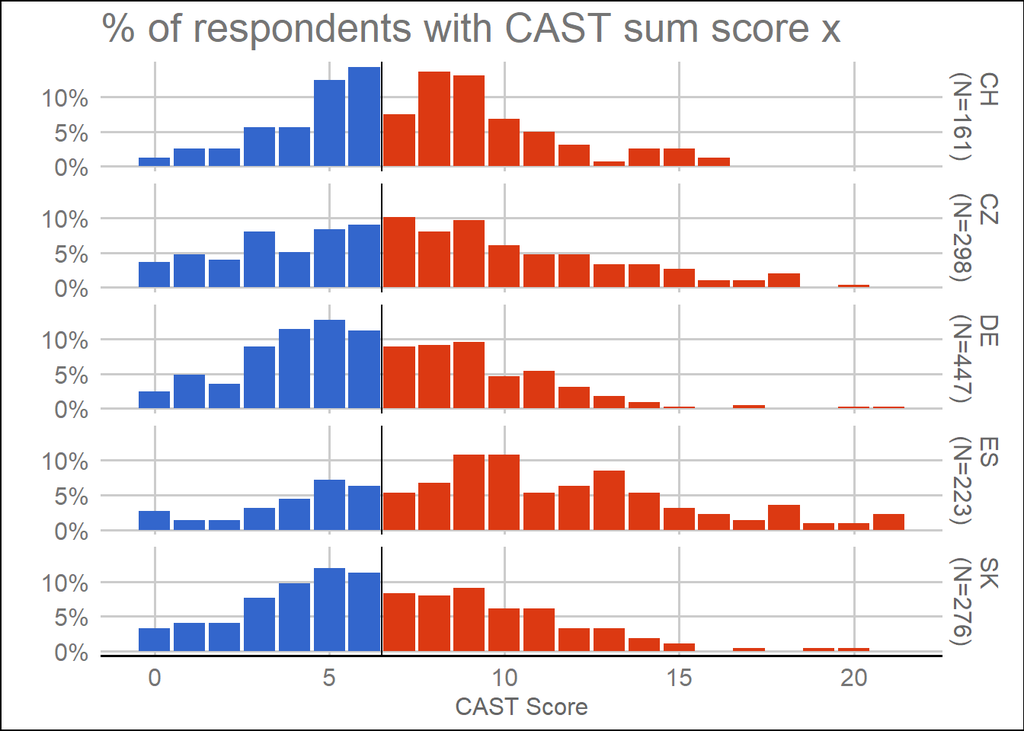

```
##        country CAST_7_or_more valid_N
##         <fctr>          <num>   <int>
## 1:     Czechia      0.5704698     298
## 2:     Germany      0.4474273     447
## 3:    Slovakia      0.4818841     276
## 4:       Spain      0.7354260     223
## 5: Switzerland      0.5590062     161
```

```
## [1] "About 50% are at risk for CUD but this percentage is higher in Spain (73%)"
```

## THC CONTENT

How is the average THC content distributed in the different countries?

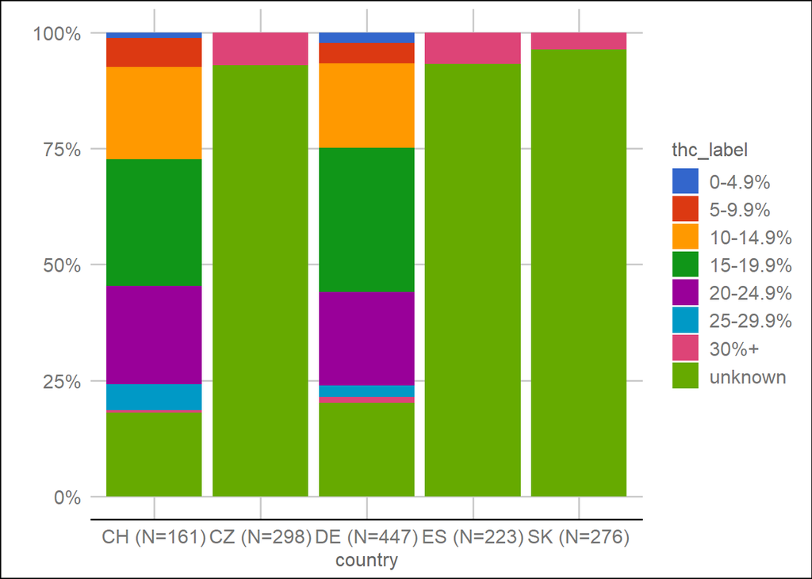

```
## [1] "Insufficient THC knowledge in CZ, ES, SK - data problem?"
```

# Cannabis amounts

## Product preference

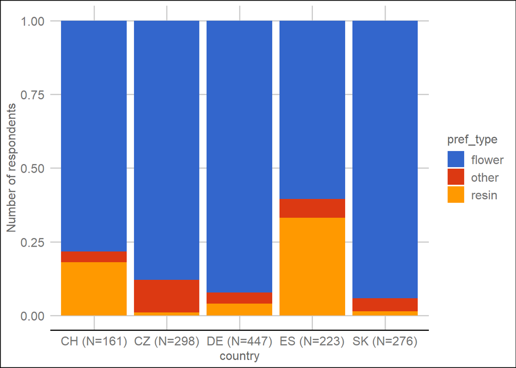

```
## [1] "High preference of cannabis flower in all countries; resin plays a role only in CH and ES"
```

## Crude Weight Assessment (CWA)

- Removed top 5% -> very large amounts (CZ: >111g; DE: >70g; SV: >60g; ES: >150g; CH: >104g) for illustration
- Analysed only flowers due to small N of resin

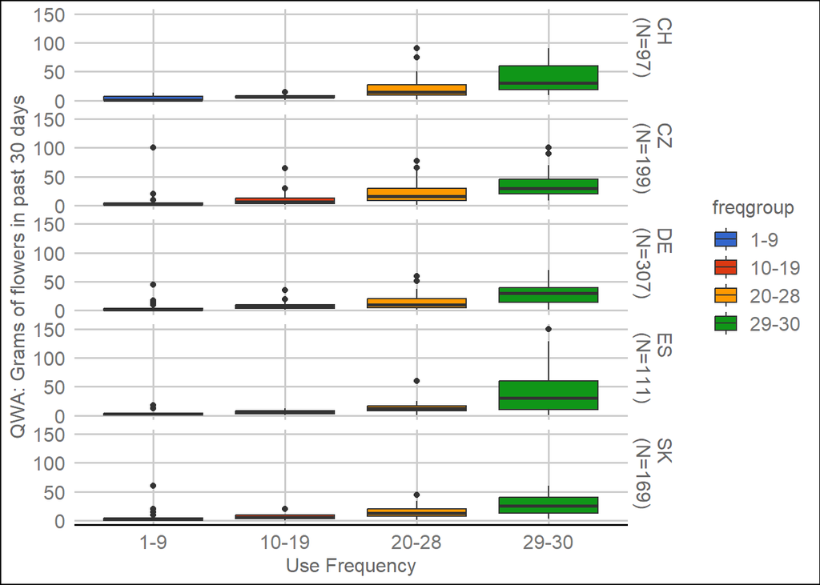

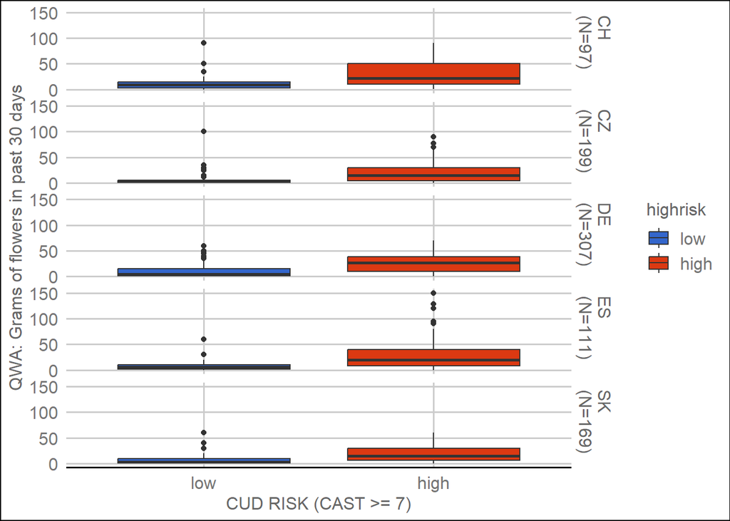

## CannaQuant Assessment (CQ)

- Removed top 5% -> very large amounts (CZ: >65; DE: >75g; SK: >96g; ES: >138g; CH: >193g) for illustration
- Analysed only flowers due to small N of resin

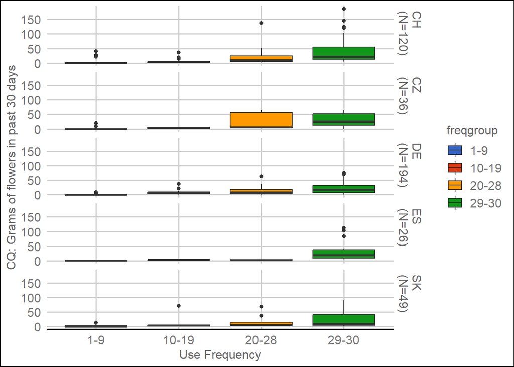

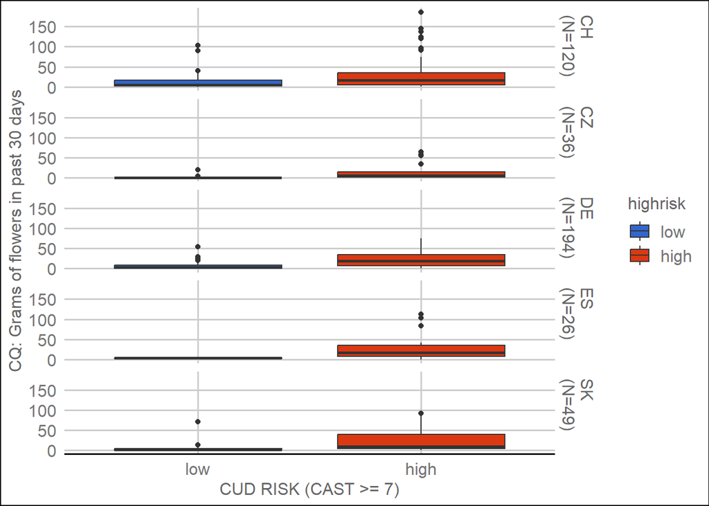